# Titanic Disaster Analysis

Basaam Malik, Srigananadh Kanipakala, Sulaiman Bashir

# Introduction

Most people, at least in the United States, have probably heard of [the Titanic](https://www.britannica.com/topic/Titanic). Though it sank over a century ago, the Titanic still occupies a space in today’s pop culture. It has shown up in TV, movies, and even children’s books. The story is captivating: how could one of the most overengineered ships in the world sink on its very first trip? We wanted to look deeper into this tragedy, and see what the data can tell us.

This topic is important because for engineers because extracting valuable insightful data from disasters like the Titanic can help avoid the same mistakes in the future. There are several points of failure for any vessel, but knowing if it was mechanical, human, etc. error can help to increase future reliability of transport. This topic is important for data science as well, as a disaster data set helps to further push data scicence's prediction cababilities to filter out the most impactful parameters and helps identify knowledge gaps within our current understanding of machine learning.

# Data Collection

The first thing we had to do was find a dataset to work with. Here are some details about the one we ended up choosing.

Source: https://data.world/nrippner/titanic-disaster-dataset

Dataset Features:

- `survival` - Survival (0 = No; 1 = Yes)
- `class` - Passenger Class (1 = 1st; 2 = 2nd; 3 = 3rd)
- `name` - Name
- `sex` - Sex
- `age` - Age
- `sibsp` - Number of Siblings/Spouses Aboard
- `parch` - Number of Parents/Children Aboard
- `ticket` - Ticket Number
- `fare` - Passenger Fare
- `cabin` - Cabin
- `embarked` - Port of Embarkation (C = Cherbourg; Q = Queenstown; S = Southampton)
- `boat` - Lifeboat (if survived)
- `body` - Body number (if did not survive and body was recovered)
- `home.dest` - Destination

```python
import folium
import requests
import pandas as  pd
import numpy as np
from folium.plugins import HeatMap
from sklearn.model_selection import train_test_split, validation_curve
from sklearn.ensemble import RandomForestClassifier
from sklearn.neighbors import KNeighborsRegressor
from sklearn.metrics import r2_score
from sklearn import tree
import matplotlib.pyplot as plt
import warnings

warnings.filterwarnings('ignore')

# Source: https://data.world/nrippner/titanic-disaster-dataset
titanic_df = pd.read_csv("https://raw.githubusercontent.com/sulby/sulby.github.io/main/titanic.csv")
titanic_df.head()
```

|  | pclass | survived | name | sex | age | sibsp | parch | ticket | fare | cabin | embarked | boat | body | home.dest |
| --- | --- | --- | --- | --- | --- | --- | --- | --- | --- | --- | --- | --- | --- | --- |
| 0 | 1.0 | 1.0 | Allen, Miss. Elisabeth Walton | female | 29.0000 | 0.0 | 0.0 | 24160 | 211.3375 | B5 | S | 2 | NaN | St Louis, MO |
| 1 | 1.0 | 1.0 | Allison, Master. Hudson Trevor | male | 0.9167 | 1.0 | 2.0 | 113781 | 151.5500 | C22 C26 | S | 11 | NaN | Montreal, PQ / Chesterville, ON |
| 2 | 1.0 | 0.0 | Allison, Miss. Helen Loraine | female | 2.0000 | 1.0 | 2.0 | 113781 | 151.5500 | C22 C26 | S | NaN | NaN | Montreal, PQ / Chesterville, ON |
| 3 | 1.0 | 0.0 | Allison, Mr. Hudson Joshua Creighton | male | 30.0000 | 1.0 | 2.0 | 113781 | 151.5500 | C22 C26 | S | NaN | 135.0 | Montreal, PQ / Chesterville, ON |
| 4 | 1.0 | 0.0 | Allison, Mrs. Hudson J C (Bessie Waldo Daniels) | female | 25.0000 | 1.0 | 2.0 | 113781 | 151.5500 | C22 C26 | S | NaN | NaN | Montreal, PQ / Chesterville, ON |

# Data Processing

## 1. Removing Unnecessary Columns

To begin processing our data, we have to figure out which data to keep, and which data we probably won't need. Luckily, if you remove some data early on and find it may be useful later, you can still add it back in.

Columns we decided to drop:

- `name` - We did not see how names would be important (unless we did some sort of fun fact section)
- `ticket` - We did not see how ticket number would be important
- `embarked` - We did not think there would be a relation between port of embarkation and survival
- `home.dest` - We did not see how someone's destination would affect their survival

```python
# Remove the columns
titanic_df.drop(columns=['name', 'ticket', 'embarked', 'home.dest'], inplace=True)
titanic_df.head()
```

|  | pclass | survived | sex | age | sibsp | parch | fare | cabin | boat | body |
| --- | --- | --- | --- | --- | --- | --- | --- | --- | --- | --- |
| 0 | 1.0 | 1.0 | female | 29.0000 | 0.0 | 0.0 | 211.3375 | B5 | 2 | NaN |
| 1 | 1.0 | 1.0 | male | 0.9167 | 1.0 | 2.0 | 151.5500 | C22 C26 | 11 | NaN |
| 2 | 1.0 | 0.0 | female | 2.0000 | 1.0 | 2.0 | 151.5500 | C22 C26 | NaN | NaN |
| 3 | 1.0 | 0.0 | male | 30.0000 | 1.0 | 2.0 | 151.5500 | C22 C26 | NaN | 135.0 |
| 4 | 1.0 | 0.0 | female | 25.0000 | 1.0 | 2.0 | 151.5500 | C22 C26 | NaN | NaN |

## 2. Removing Columns Without Enough Entries

Next, we need to remove columns that don't have enough entries. A column can descibe something super useful, but it won't help you much if it only has information for one item. When trying to see how many entries are null, the `info()` method is a good place to start. Along with the column names, `info()` will tell us how many empty, or null, entries there are in each column.

```python
# Get key info about our DataFrame
titanic_df.info()
```

```
<class 'pandas.core.frame.DataFrame'>
RangeIndex: 1310 entries, 0 to 1309
Data columns (total 10 columns):
 #   Column    Non-Null Count  Dtype
---  ------    --------------  -----
 0   pclass    1309 non-null   float64
 1   survived  1309 non-null   float64
 2   sex       1309 non-null   object
 3   age       1046 non-null   float64
 4   sibsp     1309 non-null   float64
 5   parch     1309 non-null   float64
 6   fare      1308 non-null   float64
 7   cabin     295 non-null    object
 8   boat      486 non-null    object
 9   body      121 non-null    float64
dtypes: float64(7), object(3)
memory usage: 102.5+ KB
```

From our counts, we can see that the `pclass`, `survived`, `sex`, `sibsp`, `parch`, and `fare` columns are missing very few entries, `age` is missing 264 entries, and `cabin`, `boat` and `body` are all missing the majority of entries. At this point, we don't need to remove any of the more sparse columns, because they all have some data that might be useful. However, we do need to be mindful that there are null entries when we use those columns.

Now, let's get rid of rows that have null entries in columns that we want to trust. Namely, the `pclass`, `survived`, `sex`, and `fare` columns.

```python
# Remove the rows where pclass, survived, sex, fare, parch, or sibsp value is null
titanic_df.dropna(subset=['pclass', 'survived', 'sex', 'fare', 'parch', 'sibsp'], inplace=True)
titanic_df.info()
```

```
<class 'pandas.core.frame.DataFrame'>
Int64Index: 1308 entries, 0 to 1308
Data columns (total 10 columns):
 #   Column    Non-Null Count  Dtype
---  ------    --------------  -----
 0   pclass    1308 non-null   float64
 1   survived  1308 non-null   float64
 2   sex       1308 non-null   object
 3   age       1045 non-null   float64
 4   sibsp     1308 non-null   float64
 5   parch     1308 non-null   float64
 6   fare      1308 non-null   float64
 7   cabin     295 non-null    object
 8   boat      486 non-null    object
 9   body      120 non-null    float64
dtypes: float64(7), object(3)
memory usage: 112.4+ KB
```

## 3. Imputation for Age Column

Our age column is missing a significant number of values. Obviously, we could remove the rows with missing values, but that might make us miss out on other important information that was in those rows. To help lessen the problem of missing values, we can try using an [imputation](https://towardsdatascience.com/6-different-ways-to-compensate-for-missing-values-data-imputation-with-examples-6022d9ca0779) technique to get estimates for what those values may have been.

Let's try using k-NN to impute missing age values. k-NN can make predictions for a point based on the point's k nearest neighbors. Our approach is based on [this tutorial](https://medium.com/@Cambridge_Spark/tutorial-introduction-to-missing-data-imputation-4912b51c34eb). First, we have to train a k-NN model using rows that we have complete data in. Then, we use our trained model to predict values for the rows where age is missing.

An advantage of using k-NN imputation is that the training data set is stored and learns from it only when it actually makes predictions, this makes it more efficient other other algorithms like SVM & Linear Regresson

```python
# knn classifier that uses the 5 nearest neighbors
knn = KNeighborsRegressor(5, weights='distance')

# get the entries that don't have an empty age
complete_entries = titanic_df[titanic_df['age'].notnull()]

# separate the complete entries into the things we are using to predict:
# pclass, survived, sex, fare, and the things we are trying to predict: age
complete_entries_other = complete_entries[['pclass', 'survived', 'sex', 'fare', 'parch', 'sibsp']]
complete_entries_age = complete_entries[['age']]

# convert sex to number (female -> 1, male -> 0) so our KNN can use the values
complete_entries_other['sex'] = (complete_entries_other['sex'] == "female").astype(float)

# train our model using our complete data entries
fitted_model = knn.fit(complete_entries_other, complete_entries_age)

# make a DataFrame with same columns the knn was trained
# on, so we can use it as input to make predictions
titanic_trimmed = titanic_df[['pclass', 'survived', 'sex', 'fare', 'parch', 'sibsp']]
titanic_trimmed['sex'] = (titanic_trimmed['sex'] == "female").astype(float)

# make our predictions, and add them to the DataFrame
imputed_ages = fitted_model.predict(titanic_trimmed)

# pure estimates
titanic_df['imputed_age_unblended'] = imputed_ages

# real values, with estimates inserted for missing values
titanic_df['imputed_age'] = titanic_df['age']

# substitute imputed values if the real age is missing
for i, row in titanic_df.iterrows():
  if np.isnan(row['age']):
    titanic_df.at[i, 'imputed_age'] = row['imputed_age_unblended']

titanic_df = titanic_df.drop('imputed_age_unblended', axis=1)

titanic_df.head()
```

|  | pclass | survived | sex | age | sibsp | parch | fare | cabin | boat | body | imputed_age |
| --- | --- | --- | --- | --- | --- | --- | --- | --- | --- | --- | --- |
| 0 | 1.0 | 1.0 | female | 29.0000 | 0.0 | 0.0 | 211.3375 | B5 | 2 | NaN | 29.0000 |
| 1 | 1.0 | 1.0 | male | 0.9167 | 1.0 | 2.0 | 151.5500 | C22 C26 | 11 | NaN | 0.9167 |
| 2 | 1.0 | 0.0 | female | 2.0000 | 1.0 | 2.0 | 151.5500 | C22 C26 | NaN | NaN | 2.0000 |
| 3 | 1.0 | 0.0 | male | 30.0000 | 1.0 | 2.0 | 151.5500 | C22 C26 | NaN | 135.0 | 30.0000 |
| 4 | 1.0 | 0.0 | female | 25.0000 | 1.0 | 2.0 | 151.5500 | C22 C26 | NaN | NaN | 25.0000 |

### Testing to see effectiveness of knn imputation

As you can see, our k-NN (or 5-NN, in this case) provided us with some values. However, you can also probably see some differences between the `age` and `imputed_age` columns. How can we tell if the imputed values are any good?

It would be nice to just find the differences between our imputed ages and the real ages. However, we can't do this. Since we would be testing with the same data we used to train, our performance results might be artificially high using this approach, which is not what we want.

Instead, we can try to answer this by setting aside the values we imputed, and testing k-NN on our original data. We split the data into two disjoint sets: the training set and the testing set. We then train our model using the training set. Once the model is trained, we can have it make predictions for items in the testing set. Since we know the correct ages for rows in our testing set, we can compare the k-NN's predictions with the actual ages, and see how well it performs. This testing approach is called holdout validation.

```python
# knn regressor
knn1 = KNeighborsRegressor(5, weights='distance')

# get the rows that aren't missing entries
complete_entries1 = titanic_df[titanic_df['age'].notnull()]
complete_entries1 = complete_entries1[['pclass', 'survived', 'sex', 'fare', 'parch', 'sibsp', 'age']]

# convert sex to number (female -> 1, male -> 0) so our KNN can use the values
complete_entries1['sex'] = (complete_entries1['sex'] == "female").astype(float)

# split the complete entries into training and testing sets
train, test = train_test_split(complete_entries1, train_size = 0.7)

# separate targets from training data; we don't want
# to use age values when trying to predict age values
train_targets = train['age']
train = train.drop('age', axis=1)

test_targets = test['age']
test = test.drop('age', axis=1)

# train our model using our complete data entries
fitted_model1 = knn1.fit(train, train_targets)

guesses = fitted_model1.predict(test)
diffs = (test_targets - guesses)
n_years = 5

print(str(len(diffs[abs(diffs) < n_years])) + " guesses out of " + str(len(test)) + " correct to within " + str(n_years) + " years")
```

```
90 guesses out of 314 correct to within 5 years
```

After running this test multiple times, it seems that our k-NN imputation is not amazing at estimation. Each time, we had the model predict 314 ages, and it normally got between 85 and 100 guesses correct to within 5 years. When the acceptable range is 10 years, it guesses right around half the time.

Here is a graph from one of our runs, showing how many of our guesses were accurate within different ranges.

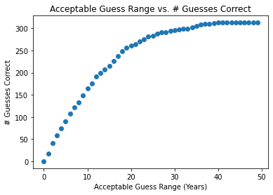

```python
pts = []
for i in range(50):
  pts.append(pd.DataFrame({'acceptable_range':[i], 'guesses_correct': [(len(diffs[abs(diffs) < i]))]}))

to_graph = pd.concat(pts)

plt.figure()
plt.scatter(to_graph['acceptable_range'], to_graph['guesses_correct'])
plt.title("Acceptable Guess Range vs. # Guesses Correct")
plt.xlabel("Acceptable Guess Range (Years)")
plt.ylabel("# Guesses Correct")
```

Now that we have this information, we have a better idea when/when not to use the data in our imputed_age column. However, we still need to keep in mind that these results don't mean that there will be the same level of accuracy when predicting ages for entries that are actually missing.

# Exploratory Data Analysis & Visualization

Now that we have processed the dataset, we can begin some analysis to find patterns in the data and visualize our features.

## Sex

Let's create a pie chart to visualize the survival rate of passengers for each sex. Below, we can see that the majority of passengers were male, yet a greater proportion and quantity of female passengers survived than male passengers.

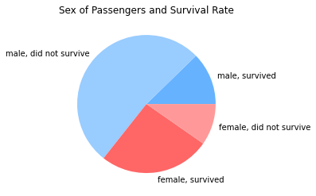

```
male, survived: 161
male, did not survive: 681
female, survived: 339
female, did not survive: 127
```

```python
# divide the dataset into male and female entries
male_entries = titanic_df[(titanic_df['sex'] == 'male')]
female_entries = titanic_df[(titanic_df['sex'] == 'female')]

# create a pie chart using the number of entries for survivors and non-survivors of each sex
sex_count = [len(male_entries[male_entries['survived'] == 1]),
            len(male_entries[male_entries['survived'] == 0]),
            len(female_entries[female_entries['survived'] == 1]),
            len(female_entries[female_entries['survived'] == 0])]
labels = ['male, survived', 'male, did not survive', 'female, survived', 'female, did not survive']
plt.figure()
plt.pie(sex_count,
        labels=labels,
        colors=['#66b2ff', '#99ccff', '#ff6666', '#ff9999'])
plt.title("Sex of Passengers and Survival Rate")
plt.show()

for count, label in zip(sex_count, labels):
  print(f'{label}: {count}')
```

## Cabin

The pie chart below shows the frequency of what cabin category passengers occupied. This is found by stripping the first letter of each cabin name. This is helpful to understand which cabins were the most dense and occupied. This may be useful to analyze as locations of cabins may have played a role in survival chances.

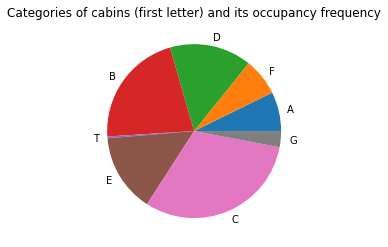

```
{'A': 22, 'F': 21, 'D': 46, 'B': 65, 'T': 1, 'E': 44, 'C': 94, 'G': 9}
```

```python
# Get all of the unique cabin names first
unique = list(set(titanic_df['cabin'].tolist()))
unique.remove(np.nan)

# Only take the 1st letter of each cabin name, it isolate it's location
result = list(set(map(lambda x: x[0], unique)))
cabins_map = {}
for letter in result:
  cabins_map[letter] = 0
  for index, row in titanic_df.iterrows():
    if letter in str(row['cabin']):
      cabins_map[letter] = cabins_map[letter]  + 1

# Display all letter-categorized cabins using pie chart
plt.pie(cabins_map.values(),labels=result)
plt.title("Categories of cabins (first letter) and its occupancy frequency")
plt.show()

print(cabins_map)
```

The bar graph below shows us the proportion of people in each cabin that survived. According to the reported cabin data, the highest survival rates were in cabins B, D, and E. (Disclaimer: there were only 295 entries for cabin data). Some possible insight to derive from this is how the cabin arrangment and ease-of-access from these locations could have impacted the overall survivability

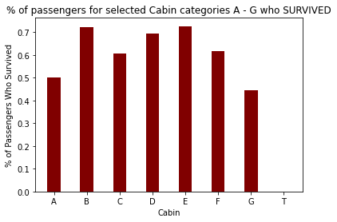

```python
result = sorted(list(set(map(lambda x: x[0], unique))))
cabins_map1 = {}
for letter in result:
  cabins_map1[letter] = 0
  for index, row in titanic_df.iterrows():
    # Only add data points if the passenger survived in that cabin
    if letter in str(row['cabin']) and row['survived'] == 1:
      cabins_map1[letter] = cabins_map1[letter]  + (1 / cabins_map[letter])

# print(cabins_map)
plt.bar(result, cabins_map1.values(), color ='maroon',
        width = 0.4)

plt.title("% of passengers for selected Cabin categories A - G who SURVIVED")
plt.xlabel("Cabin")
plt.ylabel("% of Passengers Who Survived")
```

## Age

Let's explore the distribution of passenger ages using a violin plot. First, we will only look at the non-null ages. We can observe a very similar distribution between survivors and non-survivors, but a higher proportion of survivors are children.

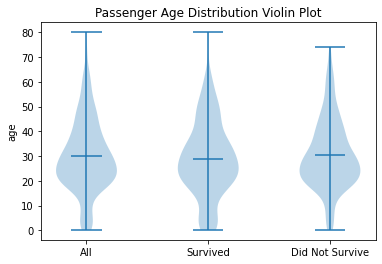

```python
# extract the ages from the dataset and separate survivors and non-survivors
ages = list(complete_entries['age'])
survivor_ages = list(complete_entries[complete_entries['survived'] == 1]['age'])
non_survivor_ages = list(complete_entries[complete_entries['survived'] == 0]['age'])
age_plots = [ages, survivor_ages, non_survivor_ages]

# create a violin plot
plt.figure()
plt.violinplot(age_plots, showmeans=True)
plt.title('Passenger Age Distribution Violin Plot')
plt.xticks([1, 2, 3], ['All', 'Survived', 'Did Not Survive'])
plt.ylabel('age')
```

Now we will repeat for the imputed ages. We can see that the violin plot still shows that survivors have a greater distribution for children.

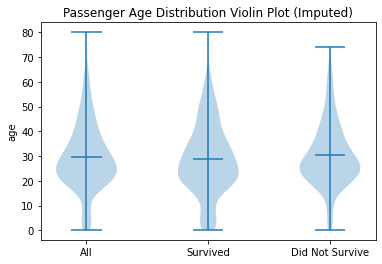

```python
# extract the imputed ages from the dataset and separate survivors and non-survivors
ages = list(titanic_df['imputed_age'])
survivor_ages = list(titanic_df[titanic_df['survived'] == 1]['imputed_age'])
non_survivor_ages = list(titanic_df[titanic_df['survived'] == 0]['imputed_age'])
age_plots = [ages, survivor_ages, non_survivor_ages]

# create a violin plot
plt.figure()
plt.violinplot(age_plots, showmeans=True)
plt.title('Passenger Age Distribution Violin Plot (Imputed)')
plt.xticks([1, 2, 3], ['All', 'Survived', 'Did Not Survive'])
plt.ylabel('age')
```

## Fare

Using another violin plot, we can visualize the distribution of fares paid by passengers. For survivors, there was a greater distribution for higher fares and higher mean fare compared to non-survivors. Additionally, there were no passengers that paid the highest fare and did not survive.

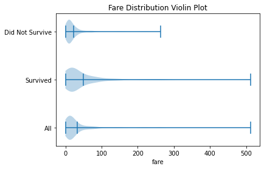

```python
# extract the fares from the dataset and separate survivors and non-survivors
fares = list(titanic_df['fare'])
survivor_fares = list(titanic_df[titanic_df['survived'] == 1]['fare'])
non_survivor_fares = list(titanic_df[titanic_df['survived'] == 0]['fare'])
fare_plots = [fares, survivor_fares, non_survivor_fares]

# create a violin plot
plt.figure()
plt.violinplot(fare_plots, showmeans=True, vert=False)
plt.title('Fare Distribution Violin Plot')
plt.yticks([1, 2, 3], ['All', 'Survived', 'Did Not Survive'])
plt.xlabel('fare')
```

## Class

Finally, let's create another pie chart to visualize the survival rate of passengers for each class (1st, 2nd, or 3rd). The pie chart below shows that passengers in higher classes survived with greater likelihood. There is a significant disparity between the survival rates of 1st Class and 3rd Class in particular.

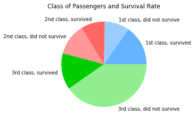

```python
class_names = ['1st', '2nd', '3rd']
pclasses = []
labels = []

# find the number of survivors and non-survivors for each class
for i in range(3):
  pclass_entries = titanic_df[(titanic_df['pclass'] == (i + 1))]
  pclasses.append(len(pclass_entries[pclass_entries['survived'] == 1]))
  labels.append(f'{class_names[i]} class, survived')
  pclasses.append(len(pclass_entries[pclass_entries['survived'] == 0]))
  labels.append(f'{class_names[i]} class, did not survive')

# create a pie chart
plt.figure()
plt.pie(pclasses, labels=labels, colors=['#66b2ff', '#99ccff', '#ff6666', '#ff9999', '#00cc00', 'lightgreen'])
plt.title("Class of Passengers and Survival Rate")
```

# Hypothesis Testing & Machine Learning

For our model, we will use a Random Forest Classifier because the dataset fits a supervised learning problem and we want to interpret how the different feature values influence survival yet have a more robust model than Decision Trees.

Additionally, we will use a Decision Tree Classifier in order to visualize the model and extract insight.

Questions:

- Did older or younger passengers have a higher change of survival?
- Did men or women have a higher chance of survival?
- Did passengers that paid a higher or lower fare have a higher chance of survival?

## Random Forest Classifier

### Splitting Data

The first step is to divide the dataset into a training set and a testing set. Specifically, we will use a proportion of 70% for training and 30% for testing. This will let us train our model, then get an idea of how well it performs.

```python
# extract the output (survival) from the dataset
y = titanic_df['survived']

# extract the features from the dataset
X = titanic_df.drop(['survived', 'age', 'cabin', 'boat', 'body'], axis=1)

# convert sex to number (female -> 1, male -> 0)
X['sex'] = (X['sex'] == "female").astype(float)

# rename the imputed_age column to age
X = X.rename(columns={'imputed_age': 'age'})

# split the data into a training set and test set
X_train, X_test, y_train, y_test = train_test_split(X, y, train_size = 0.7, random_state=0)
```

### Choosing Hyperparameters

The Random Forest model has a few hyperparameters, including the number of decision trees in the forest (`n_estimators`) and the maximum depth of the tree (`max_depth`), that we can adjust before training. We want to aim for high performance on both our training set and the test set and avoid overfitting. For more information about hyperparameters, see [this article](https://towardsdatascience.com/hyperparameter-tuning-the-random-forest-in-python-using-scikit-learn-28d2aa77dd74).

First, we will look at `n_estimators`. To optimize this value, we will compare the training and testing accuracies of a models using different values of the hyperparameter in isolation with the `sklearn` `validation_curve()` method. Based on plots after running multiple times, we can see that the optimal value for `n_estimators` is on average `n_estimators=85`.

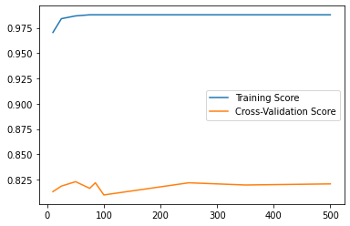

```python
# a list of the hyperparameter values being tested
n_estimator_values = [10, 25, 50, 75, 85, 100, 250, 350, 500]

# compute the training and testing accuracies for each value of n_estimator
train_score, test_score = validation_curve(RandomForestClassifier(),
                                    X = X_train,
                                    y = y_train,
                                    param_name = 'n_estimators',
                                    param_range = n_estimator_values,
                                    cv = 3)


# create a plot of the scores
plt.figure()
plt.plot(n_estimator_values, np.mean(train_score, axis=1), label='Training Score')
plt.plot(n_estimator_values, np.mean(test_score, axis=1), label='Cross-Validation Score')
plt.legend()

n_estimators = 85
```

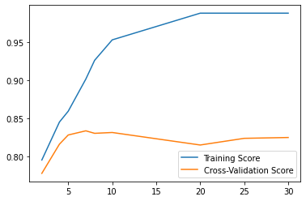

```python
# a list of the hyperparameter values being tested
max_depths = [2, 4, 5, 7, 8, 10, 20, 25, 30]

# compute the training and testing accuracies for each value of max_depth
train_score, test_score = validation_curve(RandomForestClassifier(n_estimators=n_estimators),
                                    X = X_train,
                                    y = y_train,
                                    param_name = 'max_depth',
                                    param_range = max_depths,
                                    cv = 3)

# create a plot of the scores
plt.figure()
plt.plot(max_depths, np.mean(train_score, axis=1), label='Training Score')
plt.plot(max_depths, np.mean(test_score, axis=1), label='Cross-Validation Score')
plt.legend()

max_depth = 4
```

### Training the Random Forest Classifier

Now that we have values for our hyperparameters, we can use them to train a Random Forest Classifier with the dataset. The accuracy we get is 81.42%.

```python
random_forest = RandomForestClassifier(random_state=0, max_depth=max_depth, n_estimators=n_estimators).fit(X_train, y_train)
print(f'Accuracy of Random Forest: {random_forest.score(X_test, y_test)}')
```

```
Accuracy of Random Forest: 0.8142493638676844
```

## Decision Tree Classifier

### Choosing Hyperparameters

`max_depth=4` to make visualization easier.

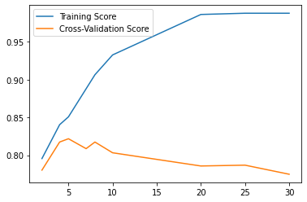

```python
# a list of the hyperparameter values being tested
max_depths = [2, 4, 5, 7, 8, 10, 20, 25, 30]

# compute the training and testing accuracies for each value of max_depth
train_score, test_score = validation_curve(tree.DecisionTreeClassifier(),
                                    X = X_train,
                                    y = y_train,
                                    param_name = 'max_depth',
                                    param_range = max_depths,
                                    cv = 3)

# create a plot of the scores
plt.figure()
plt.plot(max_depths, np.mean(train_score, axis=1), label='Training Score')
plt.plot(max_depths, np.mean(test_score, axis=1), label='Cross-Validation Score')
plt.legend()

max_depth = 4
```

### Training the Decision Tree Classifier

Now that we have a value for our hyperparameter, we can train a Decision Tree Classifier with the dataset. The accuracy we get is 82.19%.

```python
decision_tree = tree.DecisionTreeClassifier(random_state=0, max_depth=max_depth).fit(X_train, y_train)
print(f'Accuracy of Decision Tree: {decision_tree.score(X_test, y_test)}')
```

```
Accuracy of Decision Tree: 0.821882951653944
```

## Visualizing the Decision Tree

We will plot the Decision Tree that we trained.

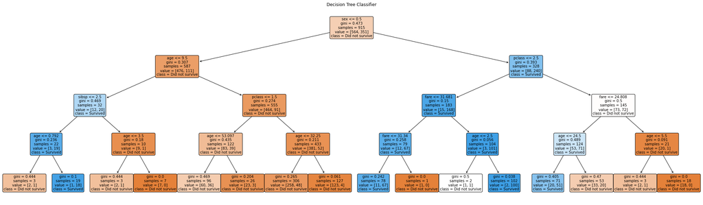

```python
plt.figure(figsize=(35,10))

tree.plot_tree(decision_tree, feature_names=X_train.columns.values, class_names=['Did not survive', 'Survived'], filled=True, rounded=True)
plt.title('Decision Tree Classifier')
```

We can also print a text-based representation of the decision tree.

```python
print(tree.export_text(decision_tree,
                  spacing=3, decimals=2, feature_names=list(X_train.columns.values)))
```

```
|--- sex <= 0.50
|   |--- age <= 9.50
|   |   |--- sibsp <= 2.50
|   |   |   |--- age <= 0.79
|   |   |   |   |--- class: 0.0
|   |   |   |--- age >  0.79
|   |   |   |   |--- class: 1.0
|   |   |--- sibsp >  2.50
|   |   |   |--- age <= 3.50
|   |   |   |   |--- class: 0.0
|   |   |   |--- age >  3.50
|   |   |   |   |--- class: 0.0
|   |--- age >  9.50
|   |   |--- pclass <= 1.50
|   |   |   |--- age <= 53.10
|   |   |   |   |--- class: 0.0
|   |   |   |--- age >  53.10
|   |   |   |   |--- class: 0.0
|   |   |--- pclass >  1.50
|   |   |   |--- age <= 32.25
|   |   |   |   |--- class: 0.0
|   |   |   |--- age >  32.25
|   |   |   |   |--- class: 0.0
|--- sex >  0.50
|   |--- pclass <= 2.50
|   |   |--- fare <= 31.68
|   |   |   |--- fare <= 31.34
|   |   |   |   |--- class: 1.0
|   |   |   |--- fare >  31.34
|   |   |   |   |--- class: 0.0
|   |   |--- fare >  31.68
|   |   |   |--- age <= 2.50
|   |   |   |   |--- class: 0.0
|   |   |   |--- age >  2.50
|   |   |   |   |--- class: 1.0
|   |--- pclass >  2.50
|   |   |--- fare <= 24.81
|   |   |   |--- age <= 24.50
|   |   |   |   |--- class: 1.0
|   |   |   |--- age >  24.50
|   |   |   |   |--- class: 0.0
|   |   |--- fare >  24.81
|   |   |   |--- age <= 5.50
|   |   |   |   |--- class: 0.0
|   |   |   |--- age >  5.50
|   |   |   |   |--- class: 0.0
```

# Insights

EDA Observations

- more men on board, but higher percentage of women survived
- highest survival rates in cabins B, D, E (limited data though)
- higher rates of children survived
- survival rates were higher among people who paid larger fares
- survival rate was higher for higher classes (1st and 2nd)

Decision Tree Insights

- our tree splits first on sex
  - men were much more likely not to survive
  - this supports the idea that they saved women and children first
- men older than 9.5 predicted not to survive
- men younger than 9.5 had higher chance of survival, number of siblings important
- for women, class was most important
  - women in 1st and 2nd class were more likely to survive
  - for 3rd class, only young women predicted to survive
  - theory: this may have been due to location of cabins for each class
    - the Titanic sank around midnight, so most passengers may have been in their cabins
    - according to deck plans from [Encyclopedia Titanica](https://www.encyclopedia-titanica.org/titanic-deckplans/profile.html), the 1st and 2nd class cabins seem to have been located higher up in the ship. Some 3rd class cabins were located near the upper decks, and some were not.